# Spatial Map

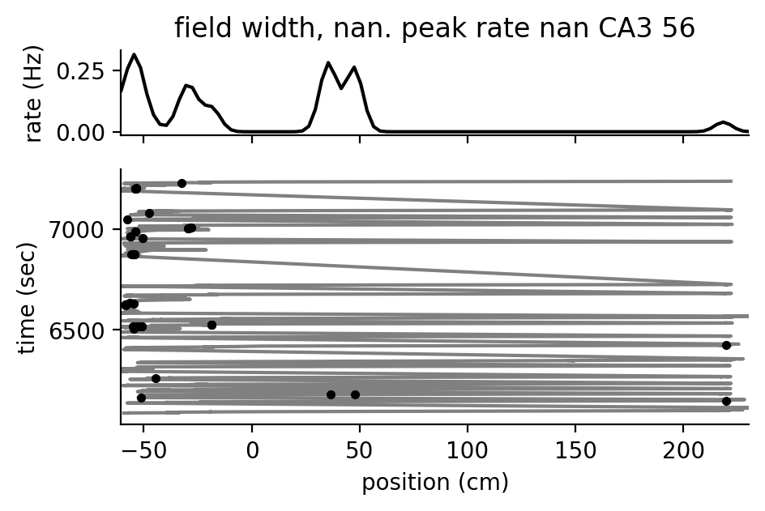

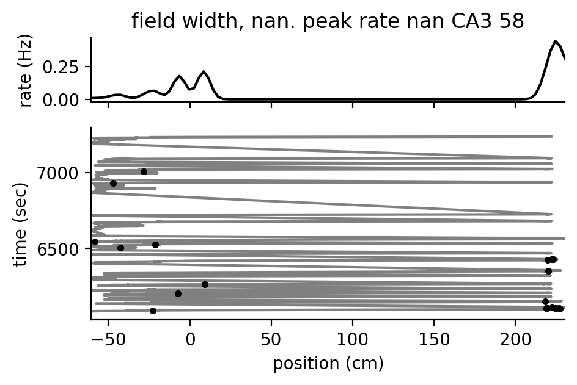

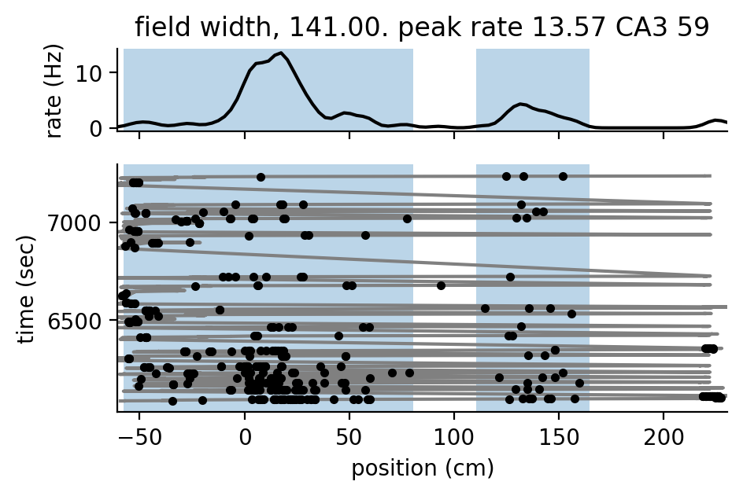

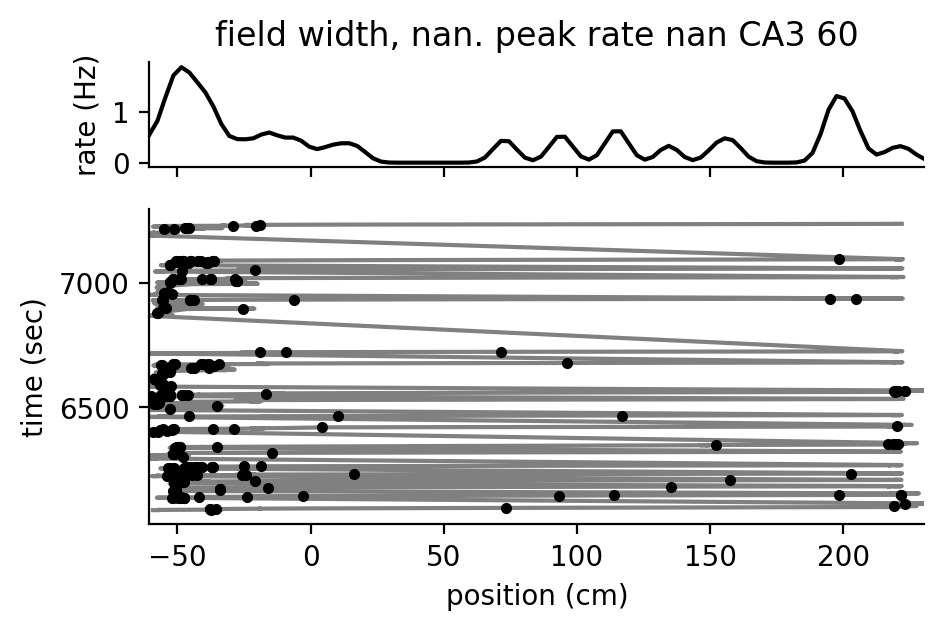

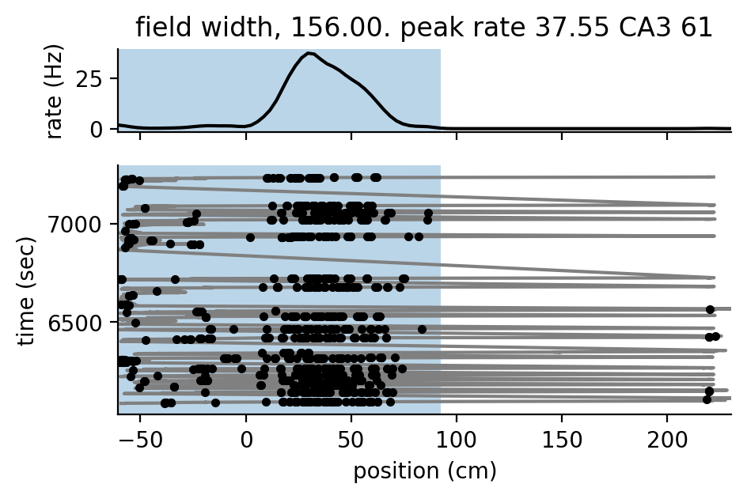

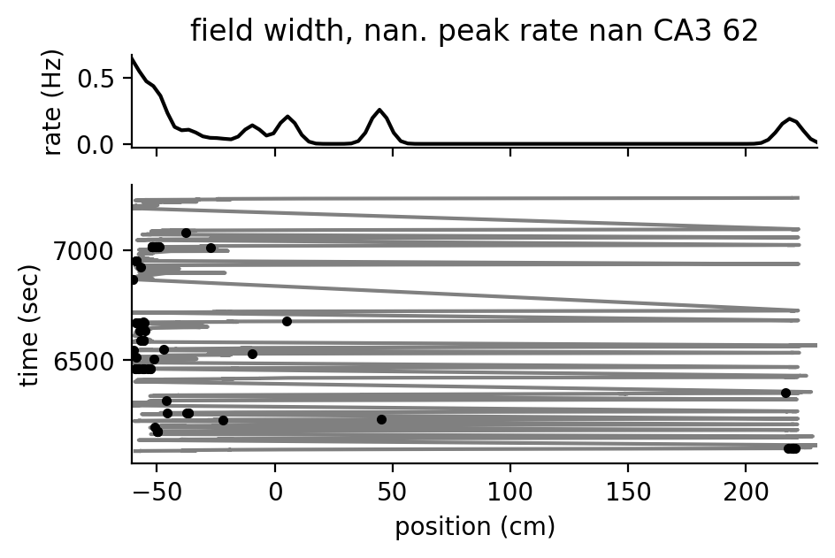

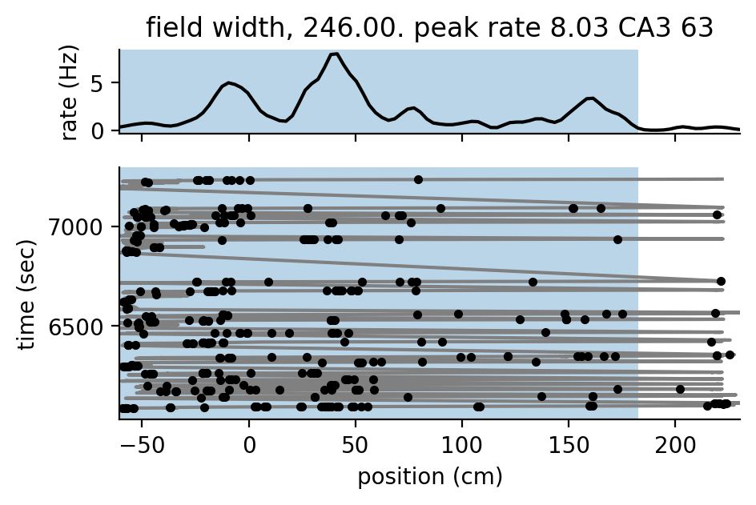

[4 more figures not shown]

## Section 7: Map continuous behavioral or neurophysiological variables

- You can map any continuous variable (speed, calcium signals, theta phase, etc.), but here we will use assembly activity

```python
basepath = r"S:\data\HMC\HMC1\day8"

# load position
position_df = loading.load_animal_behavior(basepath)

# put position into a nelpy position array for ease of use
pos = nel.AnalogSignalArray(
    data=position_df["linearized"].values.T,
    timestamps=position_df.timestamps.values,
)

behavior_idx = 1

# load epoch data
epoch_df = loading.load_epoch(basepath)
beh_epochs = nel.EpochArray(np.array([epoch_df.startTime, epoch_df.stopTime]).T)

pos = pos[beh_epochs[behavior_idx]]

# get outbound and inbound epochs
outbound_epochs, inbound_epochs = get_linear_track_lap_epochs(
    pos.abscissa_vals, pos.data[0], newLapThreshold=20
)

# calculate speed
speed = nel.utils.ddt_asa(pos, smooth=True, sigma=0.250, norm=True)
run_epochs = nel.utils.get_run_epochs(speed, v1=4, v2=4).merge()


assembly_react = AssemblyReact(
    basepath=basepath,
    brainRegion="CA1",
    putativeCellType="Pyr",
    z_mat_dt=0.01,
)

# load need data (spikes, ripples, epochs)
assembly_react.load_data()

# load theta epochs
state_dict = loading.load_SleepState_states(basepath)
theta_epochs = nel.EpochArray(
    state_dict["THETA"],
)

assembly_react.get_weights(epoch=beh_epochs[behavior_idx] & theta_epochs)
assembly_react
```

```
<AssemblyReact: 75 units, 15 assemblies> of length 6:36:57:689 hours
```

### Section 7.1: Visualize assembly weights

```python
assembly_react.plot()
plt.show()
```

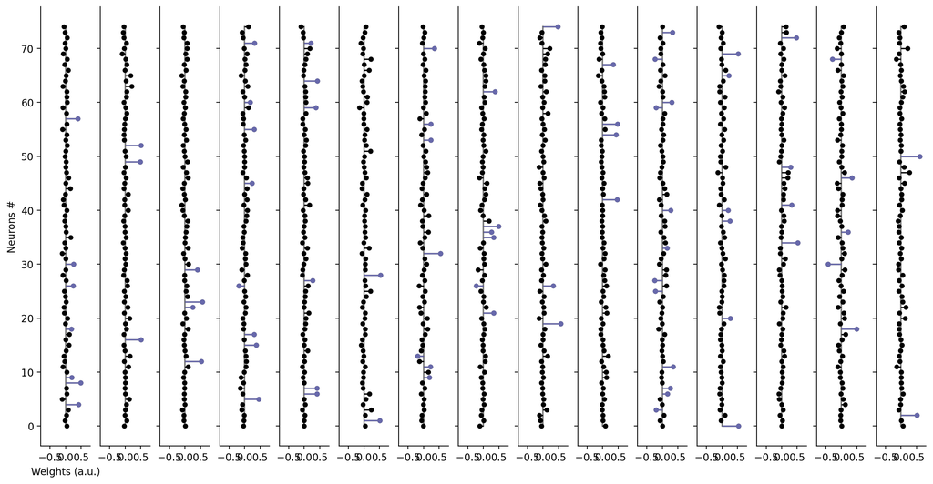

### Section 7.2: Compute time-resolved activations for each assembly

These are continous signals that we can now map using the SpatialMap class

```python
assembly_act = assembly_react.get_assembly_act(epoch=beh_epochs[behavior_idx])
assembly_act
```

```
<AnalogSignalArray at 0x21bf085c210: 15 signals> for a total of 36:48:240 minutes
```

### Section 7.3: Calculate spatial maps for each assembly for both directions

```python
spatial_map_outbound_assembly = maps.SpatialMap(
    pos[outbound_epochs],
    assembly_act[outbound_epochs],
    speed=speed,
    tuning_curve_sigma=6,
    min_duration=0,
)

spatial_map_inbound_assembly = maps.SpatialMap(
    pos[inbound_epochs],
    assembly_act[inbound_epochs],
    speed=speed,
    tuning_curve_sigma=6,
    min_duration=0,
)
```

### Section 7.4: Visualize spatial maps for each assembly

```python
for tc in [spatial_map_outbound_assembly.tc, spatial_map_inbound_assembly.tc]:
    w, h = set_size("thesis", fraction=0.3, subplots=(3, 1))

    with npl.FigureManager(show=True, figsize=(w, h)) as (fig_, ax):
        npl.utils.skip_if_no_output(fig_)
        ax1 = npl.plot_tuning_curves1D(
            tc.reorder_units(), normalize=True, pad=1, fill=True, alpha=0.5
        )

        leg_lines = ax1.get_lines()
        plt.setp(leg_lines, linewidth=0.5)
        ax.set_xlabel("position (cm)")
        ax.set_ylabel("n assemblies")
        ax.set_xticks([0, tc.bins.max()])
```

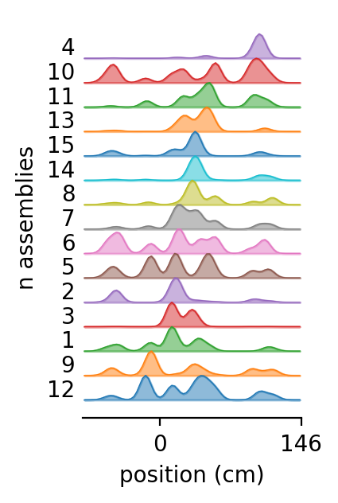

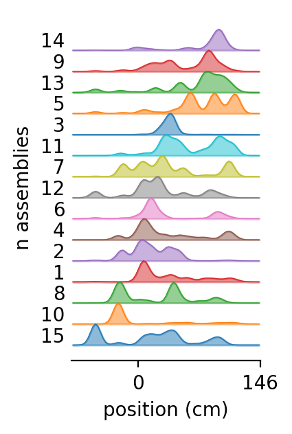

### Section 7.5: Visualize spatial maps of running speed

```python
basepath = r"R:\data\latentseq\RM10\rm10_day5_20250809"
epoch_df = npy.io.load_epoch(basepath)
beh_epochs = nel.EpochArray(epoch_df[["startTime", "stopTime"]].values)

position = npy.io.load_animal_behavior(basepath)

pos = nel.AnalogSignalArray(
    [position.x.values, position.y.values],
    timestamps=position.timestamps.values,
    fs=position.sr.unique()[0],
)

speed = nel.utils.ddt_asa(pos, smooth=True, sigma=0.250, norm=True)

behavior_idx = 2
```

```python
spatial_map_speed = maps.SpatialMap(
    pos[beh_epochs[behavior_idx]],
    speed,
    speed=speed,
    speed_thres=0,
    s_binsize=2,
    tuning_curve_sigma=1.5,
    min_duration=0,
)
ratemap = spatial_map_speed.ratemap[0, ...].copy()
ratemap[spatial_map_speed.occupancy == 0] = np.nan

extent = [
    spatial_map_speed.xbin_centers[0],
    spatial_map_speed.xbin_centers[-1],
    spatial_map_speed.ybin_centers[0],
    spatial_map_speed.ybin_centers[-1],
]
fig, ax = plt.subplots(1, 2, figsize=(13, 4),sharey=True,sharex=True)

sc = ax[0].scatter(
    pos[beh_epochs[behavior_idx]].data[0],
    pos[beh_epochs[behavior_idx]].data[1],
    c=speed[beh_epochs[behavior_idx]].data.flatten(),
    s=4,
)
# add color bar
fig.colorbar(sc, ax=ax[0], label="Running speed (cm/s)")
ax[0].set_aspect("equal")
ax[0].set_xlabel("X position (cm)")
ax[0].set_ylabel("Y position (cm)")
ax[0].set_title("Position colored by running speed")

im = ax[1].imshow(
    ratemap.T,
    extent=extent,
    origin="lower",
    # aspect="auto",
)
fig.colorbar(im, ax=ax[1], label="Average running speed")

ax[1].set_xlabel("X position (cm)")
ax[1].set_ylabel("Y position (cm)")
ax[1].set_aspect("equal")
ax[1].set_title("Spatial map of running speed")

sns.despine()
plt.show()
```

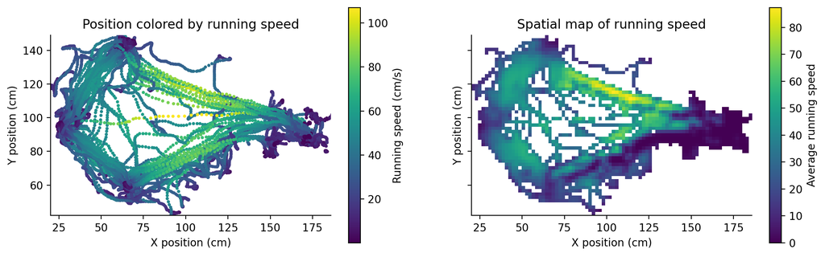